# Función normal segunda parte

Probabilidad Aplicada 3-602

## Valores aleatorios de una distribución normal

Supongamos que tenemos una distribución normal con media 0 y desvío 1. La variable aleatoria, toma infinitos valores entre $(-\infty;\infty)$.

Vamos a tomar 10 valores de la variables aleatoria en forma aleatoria.

```r
rnorm(10, 0, 1)
```

```
##  [1]  0.39526837 -0.58818417  1.07407959 -0.05599973 -0.25326721  2.20649174
##  [7]  0.54605297 -1.32694044 -1.37745311  1.27069226
```

```r
n <- 10  #tamaño de la muestra
muestra <- rnorm(n, 0, 1)
muestra
```

```
##  [1] -0.1865474 -1.6966875 -0.6862633 -0.2308261  0.7119595 -2.5929641
##  [7]  1.0560514  1.0657530 -1.9191585  0.1361645
```

```r
# Convertimos la muestra en un dataframe
muestra <- data.frame(muestra)
```

```r
muestra <- muestra %>%
    arrange(muestra)
muestra
```

```
##       muestra
## 1  -2.5929641
## 2  -1.9191585
## 3  -1.6966875
## 4  -0.6862633
## 5  -0.2308261
## 6  -0.1865474
## 7   0.1361645
## 8   0.7119595
## 9   1.0560514
## 10  1.0657530
```

Para cada valor en la muestra vamos a calcular su probabilidad con pnorm.

Para ello, al dataframe le agregamos una columna que se llame probabilidad. Sugerencia, utilizar la función mutate().

```r
data <- muestra %>%
    mutate(Probabilidad = pnorm(muestra, 0, 1))
data
```

```
##       muestra Probabilidad
## 1  -2.5929641  0.004757635
## 2  -1.9191585  0.027482139
## 3  -1.6966875  0.044877879
## 4  -0.6862633  0.246273531
## 5  -0.2308261  0.408724941
## 6  -0.1865474  0.426007768
## 7   0.1361645  0.554154370
## 8   0.7119595  0.761755064
## 9   1.0560514  0.854527625
## 10  1.0657530  0.856732349
```

Calculamos la densidad para cada punto y se lo agregamos al dataframe

```r
data <- data %>%
    mutate(Densidad = dnorm(muestra, 0, 1))
data
```

```
##       muestra Probabilidad   Densidad
## 1  -2.5929641  0.004757635 0.01383339
## 2  -1.9191585  0.027482139 0.06325866
## 3  -1.6966875  0.044877879 0.09457967
## 4  -0.6862633  0.246273531 0.31524120
## 5  -0.2308261  0.408724941 0.38845464
## 6  -0.1865474  0.426007768 0.39206074
## 7   0.1361645  0.554154370 0.39526102
## 8   0.7119595  0.761755064 0.30962863
## 9   1.0560514  0.854527625 0.22842193
## 10  1.0657530  0.856732349 0.22608296
```

Mostramos en tabla el dataframe

```r
data %>%
    kbl() %>%
    kable_styling(full_width = F)
```

| muestra | Probabilidad | Densidad |
| --- | --- | --- |
| -2.5929641 | 0.0047576 | 0.0138334 |
| -1.9191585 | 0.0274821 | 0.0632587 |
| -1.6966875 | 0.0448779 | 0.0945797 |
| -0.6862633 | 0.2462735 | 0.3152412 |
| -0.2308261 | 0.4087249 | 0.3884546 |
| -0.1865474 | 0.4260078 | 0.3920607 |
| 0.1361645 | 0.5541544 | 0.3952610 |
| 0.7119595 | 0.7617551 | 0.3096286 |
| 1.0560514 | 0.8545276 | 0.2284219 |
| 1.0657530 | 0.8567323 | 0.2260830 |

Calculamos el desvío y la media de la muestra

```r
x_raya <- mean(data$muestra)
s_d <- sd(data$muestra)
```

Lo presentamos en un cuadro de salida

```r
resumen_data <- data.frame(Tamaño_muestral = n, Media_muestral = x_raya, Desvio_muestral = s_d)
resumen_data <- resumen_data %>%
    mutate(Numero_muestra = nrow(resumen_data))
# reordeno
resumen_data <- resumen_data %>%
    select(Numero_muestra, Tamaño_muestral, Media_muestral, Desvio_muestral)
resumen_data %>%
    kbl() %>%
    kable_styling(full_width = F)
```

| Numero_muestra | Tamaño_muestral | Media_muestral | Desvio_muestral |
| --- | --- | --- | --- |
| 1 | 10 | -0.4342519 | 1.279547 |

Graficamos la probabilidad vs los cuantiles

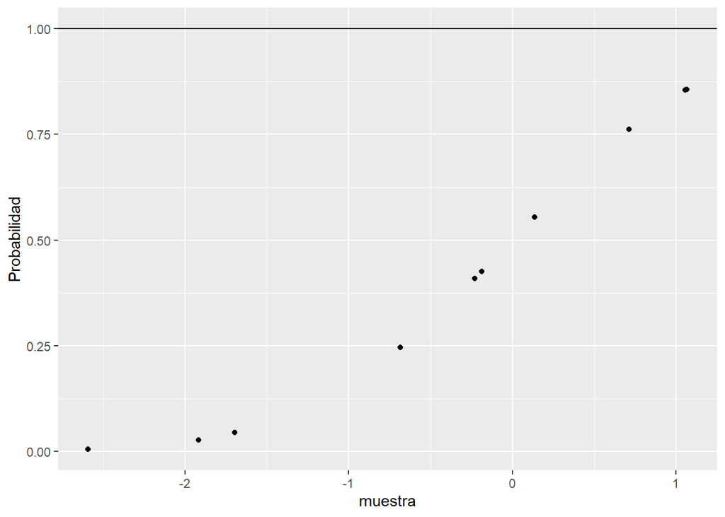

```r
g1 <- ggplot(data = data, mapping = aes(x = muestra, y = Probabilidad)) + geom_point() +
    geom_hline(yintercept = 1)
g1
```

Graficamos la densidad en funcion de los puntos muestrales.

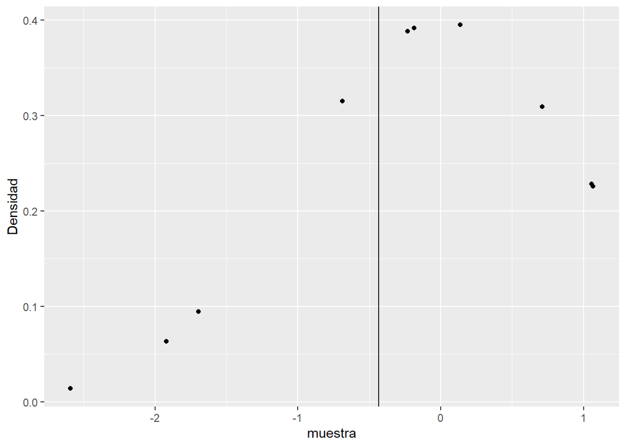

```r
g2 <- ggplot(data = data, mapping = aes(x = muestra, y = Densidad)) + geom_point() +
    geom_vline(xintercept = x_raya)
g2
```

Repetimos todo, tomando 10 muestras de tamaño 100.

Necesitamos de una función que nos ayude con las muestras y organice un dataframe que registre para cada muestra tomada, su media y desvío.

```r
resumen = function(n, mu, sigma) {
    muestra = rnorm(n, mu, sigma)
    media_muestral = mean(muestra)
    desvio_muestral = sd(muestra)
    return(salida = data.frame(media_muestral = media_muestral, desvio_muestral = desvio_muestral))
}
```

```r
m1 <- resumen(100, 0, 1)
m2 <- resumen(100, 0, 1)
m3 <- resumen(100, 0, 1)
m4 <- resumen(100, 0, 1)
m5 <- resumen(100, 0, 1)
m6 <- resumen(100, 0, 1)
m7 <- resumen(100, 0, 1)
m8 <- resumen(100, 0, 1)
m9 <- resumen(100, 0, 1)
m10 <- resumen(100, 0, 1)
res <- rbind(m1, m2, m3, m4, m5, m6, m7, m8, m9, m10)
res <- res %>%
    mutate(muestra_numero = 1:nrow(res)) %>%
    dplyr::arrange(media_muestral)

res %>%
    kbl() %>%
    kable_styling(full_width = F)
```

| media_muestral | desvio_muestral | muestra_numero |
| --- | --- | --- |
| -0.0781948 | 1.0444650 | 5 |
| -0.0103977 | 0.9902152 | 2 |
| -0.0008235 | 1.0844489 | 10 |
| 0.0019311 | 0.8532266 | 9 |
| 0.0123446 | 1.0774153 | 1 |
| 0.0299469 | 1.0645085 | 7 |
| 0.0342436 | 1.0641646 | 8 |
| 0.0439936 | 0.9395581 | 4 |
| 0.0701748 | 0.9301112 | 3 |
| 0.0976328 | 1.0438268 | 6 |

Graficamos un histograma de las medias…

```r
g <- ggplot(data = res, mapping = aes(x = media_muestral)) + geom_histogram(aes(y = ..density..),
    colour = 1, fill = "lightblue") + geom_density(lwd = 1, colour = 4)
```

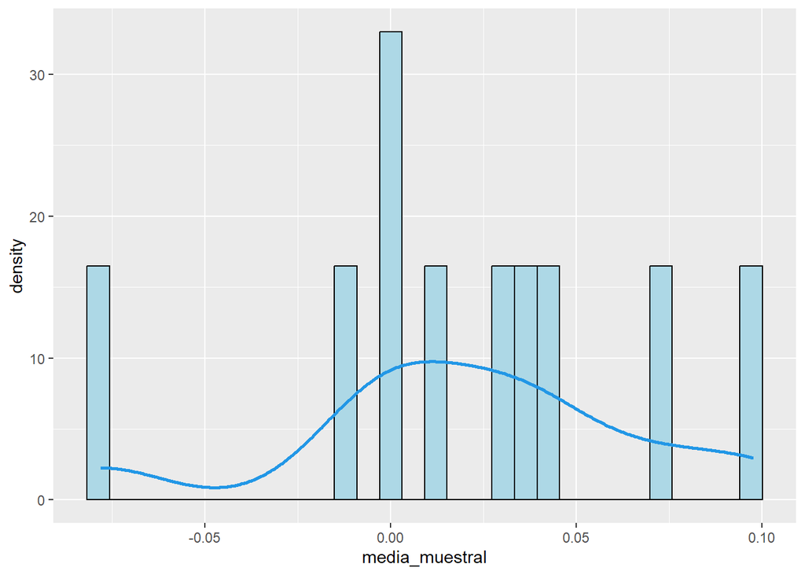

```r
g
```

Qué pasa si queremos repetir este proceso 100 veces? tomar 100 muestras de tamaño 10 o de tamaño 100 o de tamaño 1000?

## Simulación de una variable aleatoria especial

Definamos una función que haga esta simulación…

```r
# Definimos la función que realiza las iteraciones
simulacion <- function(I, n, mu, sigma) {
    # En primer lugar, definimos la función resumen, dentro de la funcion
    # generalizadora

    resumen = function(n, mu, sigma) {
        muestra = rnorm(n, mu, sigma)
        media_muestral = mean(muestra)
        desvio_muestral = sd(muestra)
        return(salida = data.frame(media_muestral = media_muestral, desvio_muestral = desvio_muestral))
    }

    # Creaamos un Dataframe vacío para almacenar los resultados
    resultado <- data.frame()
    # Creamos un ciclo for que en cada iteracción, genere una muestra y calcule
    for (i in 1:I) {
        # Llamamos a la función resumen y obtenemos el dataframe en cada
        # iteracion
        df <- resumen(n, mu, sigma)
        # Unificamos el Dataframe actual con el dataframe vacío llamado
        # resultado
        resultado <- rbind(resultado, df)

    }

    # Reiniciamos los índices del Dataframe resultado
    rownames(resultado) <- NULL
    # Agregamos una columna con el tamaño muestral
    resultado <- resultado %>%
        mutate(Muestreo_numero = 1:nrow(resultado))
    # Reordenamos las columnas del dataframe
    resultado <- resultado %>%
        select(Muestreo_numero, media_muestral, desvio_muestral)

    return(resultado)
}
```

Ahora aplicamos la función generalizadora para tomar 1000 muestras de tamaño 10, de la variable normal con media $\mu=0$ y desvío $\sigma=1$

```r
I <- 1000  #cantidad de iteraciones
n <- 10  #tamaño de muestra
mu <- 0
sigma <- 1
m <- simulacion(I, n, mu, sigma)
head(m)
```

```
##   Muestreo_numero media_muestral desvio_muestral
## 1               1    -0.38164370       1.1512958
## 2               2    -0.25675059       1.0067092
## 3               3    -0.31487590       0.9257440
## 4               4     0.26286762       0.8376267
## 5               5    -0.20012646       0.9783169
## 6               6    -0.01038849       1.2673561
```

Graficamos un histograma de las medias…

```r
g <- ggplot(data = m, mapping = aes(x = media_muestral)) + geom_histogram(aes(y = ..density..),
    colour = 1, fill = "lightblue") + geom_density(lwd = 1, colour = 4)
```

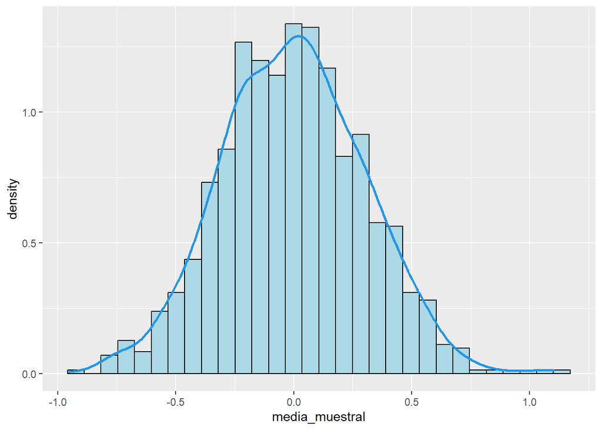

```r
g
```

Repetimos: tomar 1000 muestras de tamaño 100, de la variable normal con media $\mu=0$ y desvío $\sigma=1$.

```r
I <- 1000  #cantidad de iteraciones
n <- 100  #tamaño de muestra
mu <- 0
sigma <- 1
m <- simulacion(I, n, mu, sigma)
head(m)
```

```
##   Muestreo_numero media_muestral desvio_muestral
## 1               1     0.02961288       1.0374177
## 2               2     0.20262138       0.9204004
## 3               3     0.17246834       0.9282662
## 4               4    -0.10902357       0.8894312
## 5               5    -0.04563441       0.9345469
## 6               6    -0.00923064       1.0284706
```

Graficamos un histograma de las medias

```r
g <- ggplot(data = m, mapping = aes(x = media_muestral)) + geom_histogram(aes(y = ..density..),
    colour = 1, fill = "lightblue") + geom_density(lwd = 1, colour = 4)
```

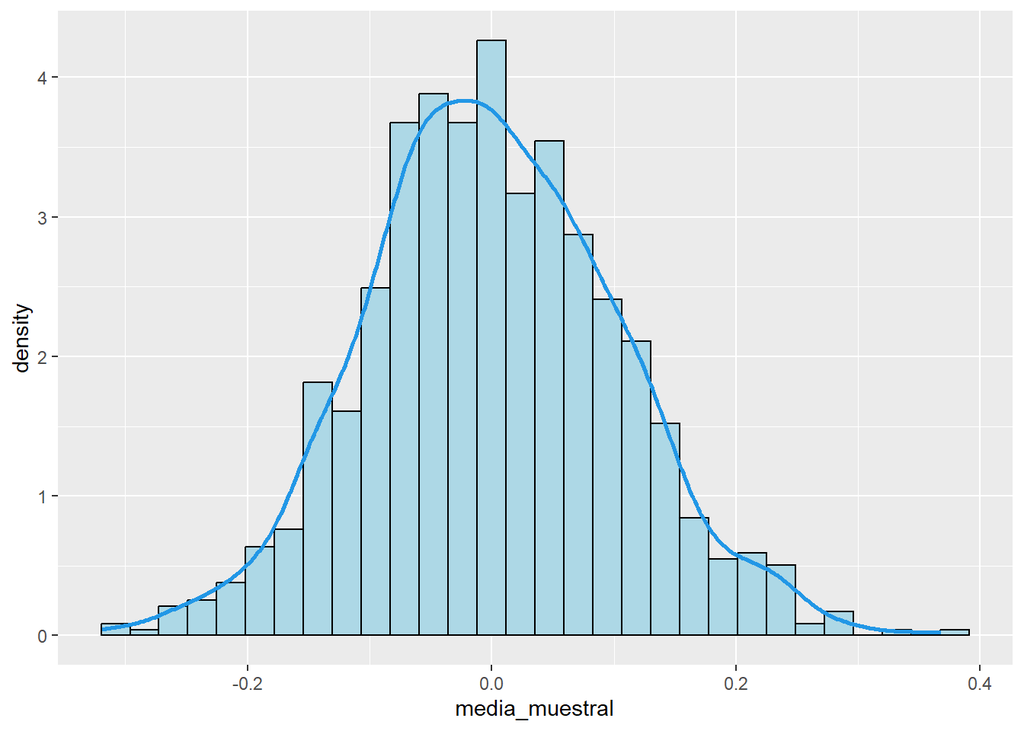

```r
g
```

Con estos ejemplos, observamos que cada muestra aporta un valor de media. Los valores de media, tienden a distribuirse normalmente.

Esto nos conduce a pensar que la media es una variable aleatoria que se distribuye normalmente.